# Word Embedding

Based on the news article, find the correlation between a given word

```python
import pandas as pd
import numpy as np
from gensim.models import word2vec
from sklearn.manifold import TSNE
import plotly_express as px
from tqdm.notebook import tqdm

import nltk
from nltk.corpus import stopwords


pd.set_option('display.max_columns', 500)
pd.set_option('display.max_rows', 500)

import warnings
warnings.filterwarnings("ignore")
```

```python
import matplotlib.pyplot as plt
%matplotlib inline
```

```python
df = pd.read_csv('covid19_news.csv') # bag default as document
df['doc_date'] = pd.to_datetime(df['doc_date'])
df.head()
```

|  | doc_content | doc_date | doc_id | doc_source | doc_title | doc_url | doc_lemma |
| --- | --- | --- | --- | --- | --- | --- | --- |
| 0 | By YANAN WANG and MIKE STOBBE\nBEIJING (AP) — ... | 2020-01-08 | 983556 | US News | Chinese Report Says Illnesses May Be From New ... | https://www.usnews.com/news/world/articles/202... | yanan wang mike stobbe beijing ( ap ) — prelim... |
| 1 | BEIJING (AP) — Health authorities in a central... | 2020-01-10 | 985558 | US News | China Reports 1st Death From New Type of Coron... | https://www.usnews.com/news/health-news/articl... | beijing ( ap ) — health authority central chin... |
| 2 | Here are some of the latest health and medical... | 2020-01-13 | 987316 | US News | Health Highlights: Jan. 13, 2020 | https://www.usnews.com/news/health-news/articl... | late health medical news development , compile... |
| 3 | Here are some of the latest health and medical... | 2020-01-14 | 988361 | US News | Health Highlights: Jan. 14, 2020 | https://www.usnews.com/news/health-news/articl... | late health medical news development , compile... |
| 4 | By MARI YAMAGUCHI, Associated Press\nTOKYO (AP... | 2020-01-16 | 989997 | US News | Patient in Japan Confirmed as Having New Virus... | https://www.usnews.com/news/world/articles/202... | mari yamaguchi , associate press tokyo ( ap ) ... |

```python
stop_words = set(stopwords.words('english'))
tokenizer = nltk.RegexpTokenizer(r"\w+") # remove punctuation
```

```python
# tokenizing
stop_words = set(stopwords.words('english'))
tokenizer = nltk.RegexpTokenizer(r"\w+") # remove punctuation

df['tokenize'] = 0

for i in tqdm(range(len(df))):
    rm_words = tokenizer.tokenize(df['doc_lemma'][i].lower())
    df['tokenize'][i] = [w for w in rm_words if not w in stop_words]
```

## Word2Vec

```python
corpus = df['tokenize']
model = word2vec.Word2Vec(corpus, size=246, window=5, min_count=200, workers=4)
```

## Visualize with tSNE

### Generate coordinates to plot

```python
coords = pd.DataFrame(index=range(len(model.wv.vocab)))
coords['label'] = [w for w in model.wv.vocab]
coords['vector'] = coords['label'].apply(lambda x: model.wv.get_vector(x))
coords.head()
```

|  | label | vector |
| --- | --- | --- |
| 0 | mike | [-0.40347514, 0.03446126, 0.1606664, -0.170688... |
| 1 | beijing | [0.5820752, -0.46440327, -0.35004845, -0.30384... |
| 2 | ap | [0.18710165, -0.4540286, -2.300964, -0.3957450... |
| 3 | viral | [0.08787581, -0.4534321, -0.5905201, 0.1099466... |
| 4 | pneumonia | [0.30953166, -0.45536315, 1.2190796, -0.227871... |

### Use ScikitLearn's TSNE library

```python
tsne_model = TSNE(perplexity=40, n_components=2, init='pca', n_iter=2500, random_state=23)
tsne_values = tsne_model.fit_transform(coords['vector'].tolist())
```

```python
coords['x'] = tsne_values[:,0]
coords['y'] = tsne_values[:,1]
coords.head()
```

|  | label | vector | x | y |
| --- | --- | --- | --- | --- |
| 0 | mike | [-0.40347514, 0.03446126, 0.1606664, -0.170688... | 10.029173 | -28.339008 |
| 1 | beijing | [0.5820752, -0.46440327, -0.35004845, -0.30384... | 16.484722 | -20.720783 |
| 2 | ap | [0.18710165, -0.4540286, -2.300964, -0.3957450... | 12.471695 | -35.546696 |
| 3 | viral | [0.08787581, -0.4534321, -0.5905201, 0.1099466... | -1.771891 | 25.571766 |
| 4 | pneumonia | [0.30953166, -0.45536315, 1.2190796, -0.227871... | 0.574031 | 31.866884 |

### Plot the coordinates

```python
px.scatter(coords, 'x', 'y', text='label', height=1000).update_traces(mode='text')
```

[interactive chart not shown]

# Semantic Algebra

## Analogy

$A : B :: C : D? \rightarrow B - A + C = D$

```python
def complete_analogy(A, B, C, n=2):
    try:
        return model.wv.most_similar(positive=[B, C], negative=[A])[0:n]
    except KeyError as e:
        print('Error:', e)
        return None
```

```python
complete_analogy('trump', 'mask', 'coronavirus')
```

```
[('wear', 0.5080183148384094), ('shortage', 0.47308841347694397)]
```

```python
complete_analogy('coronavirus', 'confirm', 'sanitizer')
```

```
[('hand', 0.5053896903991699), ('water', 0.4674760699272156)]
```

```python
complete_analogy('government', 'trump', 'china')
```

```
[('attack', 0.4383780360221863), ('history', 0.417108952999115)]
```

## Similar word

### Trump

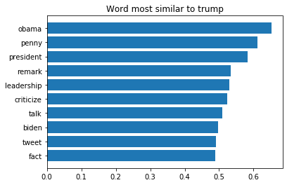

```python
def plot_similar_word(word):

    testList2 = model.wv.most_similar(str(word))
    testList2 = sorted(testList2, key=lambda x: x[1], reverse=False)
    plt.barh(*zip(*testList2));
    plt.title('Word most similar to ' + str(word));

plot_similar_word('trump')
```

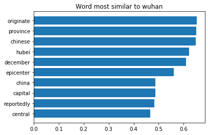

```python
plot_similar_word('wuhan')
```

### Coronavirus

We can clearly identify what a coronavirus is in the news paper by the correlation. That is, we can learn it is a virus, disease and grow rapidly, and potential spread worldwide without prior knowledge.

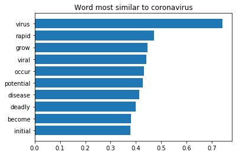

```python
plot_similar_word('coronavirus')
```

### Hand

For these articles related to coronavirus, we can learn that we should avoid touching things with our hands and to our face, because **wash, sanitizer, and glove** is highly correlated to hand. That is, those words indicate we should wash our hands with sanitizer and it is better to wear a gloves if necessary.

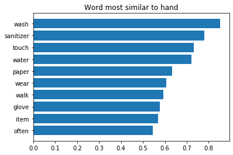

```python
plot_similar_word('hand')
```

### Mask

The highly correlated word with mask shows the same protective items such as glove, sanitizer, and we can also know mask is a protective item for coronavirus

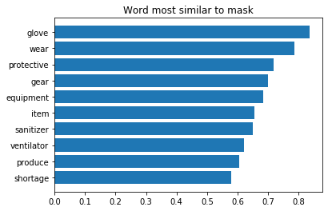

```python
plot_similar_word('mask')
```